# Análisis cluster - Método jerarquico - Ejemplo cereales

# **1**. Para estudiar de las características nutricionales de los cereales en copos de consumo habitual, se obtuvo una muestra de 43 productos disponibles en el mercado.El conjunto de datos se encuentra en el archivo ‘datoscereales.xls’.

## *1.1* Describir el conjunto de datos.

Cargar las librerías necesarias

```r
library(readxl)
library(dplyr)
library(factoextra)
library(knitr)
library(psych)
library(cowplot)
library(ggdendro)
```

Fijar un directorio

```r
data_path  <- here::here("datos")
```

Nombre del archivo a leer

```r
data_name  <- "datoscereales.xls"
```

Leer los datos de los cereales en copos

```r
df <- read_xls(
  file.path(data_path, data_name)
  ) %>%
  dplyr::mutate(
    marca   = factor(marca),
    publico = factor(publico),
    paquete = factor(paquete)
  )
```

Describir el conjunto de datos

```r
str(df)
```

```
## tibble [43 × 15] (S3: tbl_df/tbl/data.frame)
##  $ id           : num [1:43] 1 2 3 4 5 6 7 8 9 10 ...
##  $ marca        : Factor w/ 6 levels "3 Arroyos","Granix",..: 3 1 1 1 2 1 6 1 2 2 ...
##  $ nombre       : chr [1:43] "All Bran Capuccino" "Almohaditas" "Almohaditas dos salvados" "Aritos de avena con almendras" ...
##  $ publico      : Factor w/ 2 levels "adultos","chicos": 1 1 1 1 1 1 1 1 2 2 ...
##  $ paquete      : Factor w/ 2 levels "bolsa","caja": 2 1 2 2 1 1 2 1 1 1 ...
##  $ preciox350g  : num [1:43] 11.05 7.48 8.75 8.65 5.55 ...
##  $ calorias     : num [1:43] 280 422 341 386 392 ...
##  $ proteinas    : num [1:43] 14 8.1 9.4 5.8 8 5.4 10 9.2 5.7 5.7 ...
##  $ carbohidratos: num [1:43] 48 60.7 68.7 85.9 87.6 13.4 64 67.5 89 89 ...
##  $ fibras       : num [1:43] 25 8.1 11 1.7 1.4 37.2 8 7.2 3.78 3.78 ...
##  $ lipidos      : num [1:43] 3.5 16.3 3.2 2.1 0.7 34.8 18 8.6 1.4 1.3 ...
##  $ sodio        : num [1:43] 260 180 204 251 970 ...
##  $ potasio      : num [1:43] 840 314 379 109 105 ...
##  $ vitamina     : num [1:43] 37.5 36.9 40.3 47.5 48.3 ...
##  $ hierro       : num [1:43] 9.38 9.05 9.21 9.53 14.43 ...
```

```r
dim(df)
```

```
## [1] 43 15
```

```r
head(df)
```

```
## # A tibble: 6 × 15
##      id marca     nombre     publico paquete preciox350g
##   <dbl> <fct>     <chr>      <fct>   <fct>         <dbl>
## 1     1 Kelloggs  All Bran … adultos caja          11.0
## 2     2 3 Arroyos Almohadit… adultos bolsa          7.48
## 3     3 3 Arroyos Almohadit… adultos caja           8.75
## 4     4 3 Arroyos Aritos de… adultos caja           8.65
## 5     5 Granix    Arroz en … adultos bolsa          5.55
## 6     6 3 Arroyos Best Bran  adultos bolsa          5.53
## # ℹ 9 more variables: calorias <dbl>, proteinas <dbl>,
## #   carbohidratos <dbl>, fibras <dbl>, lipidos <dbl>,
## #   sodio <dbl>, potasio <dbl>, vitamina <dbl>,
## #   hierro <dbl>
```

```r
summary(df)
```

```
##        id             marca       nombre
##  Min.   : 1.0   3 Arroyos:11   Length:43
##  1st Qu.:11.5   Granix   : 7   Class :character
##  Median :22.0   Kelloggs :13   Mode  :character
##  Mean   :22.0   Nestlé   : 9
##  3rd Qu.:32.5   Nutridía : 2
##  Max.   :43.0   Quaker   : 1
##     publico    paquete    preciox350g
##  adultos:27   bolsa:13   Min.   : 3.272
##  chicos :16   caja :30   1st Qu.: 5.980
##                          Median : 8.826
##                          Mean   : 8.765
##                          3rd Qu.:10.660
##                          Max.   :14.656
##     calorias       proteinas      carbohidratos
##  Min.   :220.0   Min.   : 3.000   Min.   :13.40
##  1st Qu.:367.0   1st Qu.: 5.150   1st Qu.:72.25
##  Median :383.0   Median : 7.000   Median :85.00
##  Mean   :374.8   Mean   : 7.135   Mean   :78.31
##  3rd Qu.:390.5   3rd Qu.: 9.050   3rd Qu.:88.17
##  Max.   :440.0   Max.   :14.000   Max.   :94.00
##      fibras          lipidos           sodio
##  Min.   : 0.000   Min.   : 0.000   Min.   :  50.0
##  1st Qu.: 1.850   1st Qu.: 0.750   1st Qu.: 290.5
##  Median : 3.000   Median : 2.100   Median : 478.0
##  Mean   : 6.383   Mean   : 4.539   Mean   : 476.5
##  3rd Qu.: 6.400   3rd Qu.: 5.150   3rd Qu.: 626.4
##  Max.   :40.700   Max.   :34.800   Max.   :1100.0
##     potasio          vitamina         hierro
##  Min.   : 27.63   Min.   :16.86   Min.   : 1.10
##  1st Qu.: 95.19   1st Qu.:39.60   1st Qu.: 9.13
##  Median :131.66   Median :48.26   Median :11.25
##  Mean   :220.30   Mean   :44.33   Mean   :10.84
##  3rd Qu.:261.48   3rd Qu.:50.00   3rd Qu.:11.90
##  Max.   :948.00   Max.   :51.00   Max.   :25.00
```

```r
skimr::skim(df)
```

Data summary

| Name | df |
| --- | --- |
| Number of rows | 43 |
| Number of columns | 15 |
| _______________________ |  |
| Column type frequency: |  |
| character | 1 |
| factor | 3 |
| numeric | 11 |
| ________________________ |  |
| Group variables | None |

**Variable type: character**

| skim_variable | n_missing | complete_rate | min | max | empty | n_unique | whitespace |
| --- | --- | --- | --- | --- | --- | --- | --- |
| nombre | 0 | 1 | 4 | 30 | 0 | 41 | 0 |

**Variable type: factor**

| skim_variable | n_missing | complete_rate | ordered | n_unique | top_counts |
| --- | --- | --- | --- | --- | --- |
| marca | 0 | 1 | FALSE | 6 | Kel: 13, 3 A: 11, Nes: 9, Gra: 7 |
| publico | 0 | 1 | FALSE | 2 | adu: 27, chi: 16 |
| paquete | 0 | 1 | FALSE | 2 | caj: 30, bol: 13 |

**Variable type: numeric**

| skim_variable | n_missing | complete_rate | mean | sd | p0 | p25 | p50 | p75 | p100 | hist |
| --- | --- | --- | --- | --- | --- | --- | --- | --- | --- | --- |
| id | 0 | 1 | 22.00 | 12.56 | 1.00 | 11.50 | 22.00 | 32.50 | 43.00 | ▇▇▇▇▇ |
| preciox350g | 0 | 1 | 8.76 | 3.02 | 3.27 | 5.98 | 8.83 | 10.66 | 14.66 | ▆▃▇▆▃ |
| calorias | 0 | 1 | 374.78 | 41.27 | 220.00 | 367.00 | 383.00 | 390.50 | 440.00 | ▁▁▁▇▂ |
| proteinas | 0 | 1 | 7.13 | 2.44 | 3.00 | 5.15 | 7.00 | 9.05 | 14.00 | ▆▆▇▂▁ |
| carbohidratos | 0 | 1 | 78.31 | 15.49 | 13.40 | 72.25 | 85.00 | 88.16 | 94.00 | ▁▁▁▂▇ |
| fibras | 0 | 1 | 6.38 | 9.40 | 0.00 | 1.85 | 3.00 | 6.40 | 40.70 | ▇▁▁▁▁ |
| lipidos | 0 | 1 | 4.54 | 6.64 | 0.00 | 0.75 | 2.10 | 5.15 | 34.80 | ▇▂▁▁▁ |
| sodio | 0 | 1 | 476.49 | 258.02 | 50.00 | 290.50 | 478.00 | 626.40 | 1100.00 | ▆▅▇▂▂ |
| potasio | 0 | 1 | 220.30 | 197.58 | 27.63 | 95.19 | 131.66 | 261.48 | 948.00 | ▇▃▁▁▁ |
| vitamina | 0 | 1 | 44.33 | 8.13 | 16.86 | 39.61 | 48.26 | 50.00 | 51.00 | ▁▁▁▂▇ |
| hierro | 0 | 1 | 10.84 | 3.10 | 1.10 | 9.13 | 11.25 | 11.90 | 25.00 | ▁▅▇▁▁ |

## *1.2* Aplicar un método de agrupamiento jerárquico considerando sólo las características nutricionales

```r
# Asignar el 'id' de los cereales como nombre de las filas
rownames(df) <- df$id

# seleccionar solo las variables de las características nutricionales
vars_to_cluster <- c(
  "calorias", "proteinas", "carbohidratos", "fibras",
  "lipidos", "sodio", "potasio", "vitamina", "hierro"
)

df_to_cluster <- df %>%
  dplyr::select(all_of(vars_to_cluster))
summary(df_to_cluster)
```

```
##     calorias       proteinas      carbohidratos
##  Min.   :220.0   Min.   : 3.000   Min.   :13.40
##  1st Qu.:367.0   1st Qu.: 5.150   1st Qu.:72.25
##  Median :383.0   Median : 7.000   Median :85.00
##  Mean   :374.8   Mean   : 7.135   Mean   :78.31
##  3rd Qu.:390.5   3rd Qu.: 9.050   3rd Qu.:88.17
##  Max.   :440.0   Max.   :14.000   Max.   :94.00
##      fibras          lipidos           sodio
##  Min.   : 0.000   Min.   : 0.000   Min.   :  50.0
##  1st Qu.: 1.850   1st Qu.: 0.750   1st Qu.: 290.5
##  Median : 3.000   Median : 2.100   Median : 478.0
##  Mean   : 6.383   Mean   : 4.539   Mean   : 476.5
##  3rd Qu.: 6.400   3rd Qu.: 5.150   3rd Qu.: 626.4
##  Max.   :40.700   Max.   :34.800   Max.   :1100.0
##     potasio          vitamina         hierro
##  Min.   : 27.63   Min.   :16.86   Min.   : 1.10
##  1st Qu.: 95.19   1st Qu.:39.60   1st Qu.: 9.13
##  Median :131.66   Median :48.26   Median :11.25
##  Mean   :220.30   Mean   :44.33   Mean   :10.84
##  3rd Qu.:261.48   3rd Qu.:50.00   3rd Qu.:11.90
##  Max.   :948.00   Max.   :51.00   Max.   :25.00
```

## *1.3* De ser necesario, estandarizar las variables. Justifique su elección.

```r
# Estandarizar las variable como paso previo
df_to_cluster <- scale(df_to_cluster)
summary(df_to_cluster)
```

```
##     calorias         proteinas        carbohidratos
##  Min.   :-3.7504   Min.   :-1.69786   Min.   :-4.1893
##  1st Qu.:-0.1885   1st Qu.:-0.81503   1st Qu.:-0.3908
##  Median : 0.1992   Median :-0.05539   Median : 0.4321
##  Mean   : 0.0000   Mean   : 0.00000   Mean   : 0.0000
##  3rd Qu.: 0.3809   3rd Qu.: 0.78638   3rd Qu.: 0.6364
##  Max.   : 1.5803   Max.   : 2.81895   Max.   : 1.0130
##      fibras             lipidos
##  Min.   :-0.678917   Min.   :-0.68374
##  1st Qu.:-0.482131   1st Qu.:-0.57075
##  Median :-0.359805   Median :-0.36738
##  Mean   : 0.000000   Mean   : 0.00000
##  3rd Qu.: 0.001855   3rd Qu.: 0.09211
##  Max.   : 3.650370   Max.   : 4.55887
##      sodio              potasio
##  Min.   :-1.652965   Min.   :-0.9751
##  1st Qu.:-0.720859   1st Qu.:-0.6332
##  Median : 0.005835   Median :-0.4486
##  Mean   : 0.000000   Mean   : 0.0000
##  3rd Qu.: 0.580989   3rd Qu.: 0.2084
##  Max.   : 2.416521   Max.   : 3.6831
##     vitamina           hierro
##  Min.   :-3.3780   Min.   :-3.1386
##  1st Qu.:-0.5808   1st Qu.:-0.5512
##  Median : 0.4836   Median : 0.1319
##  Mean   : 0.0000   Mean   : 0.0000
##  3rd Qu.: 0.6976   3rd Qu.: 0.3413
##  Max.   : 0.8206   Max.   : 4.5623
```

```r
# Calcular las distancias
d   <- dist(df_to_cluster, method = "euclidean")
```

Las distancias que se pueden calcular cambiando el argumento de ‘*method*’, son:

“maximum”, “manhattan”, “canberra”, “binary” (complemento de Jaccard), y “minkowski” (es necesario agregar a las opciones la potencia y raiz. Si p=2 -euclidea-)

**Otras sentencias para calculo de distancias/similaridades:**

- Utilizando la función ‘dist.binary()’ del paquete ‘ade4’ distintas distancias para variables dicotómicas:

distancia <- dist.binary(df, method = 2, diag = FALSE, upper = FALSE)

Para elegir la funcion de distancia, se seleccionar un nro de 1 a 10 *para* el argumento ‘*method*’ (si pongo NULL me sale la ayuda)

1. JACCARD s1 = a/(a+b+c) –> d = sqrt(1 - s)

2. SM, SOCKAL & MICHENER s2 = (a+d)/(a+b+c+d) –> d = sqrt(1 - s)

3. SOCKAL & SNEATH s3 = a/(a+2(b+c)) –> d = sqrt(1 - s)

4. ROGERS & TANIMOTO s4 = (a+d)/(a+2(b+c)+d) –> d = sqrt(1 - s)

5. CZEKANOWSKI or SORENSEN s5 = 2*a/(2*a+b+c) –> d = sqrt(1 - s)

6. s6 = (a-(b+c)+d)/(a+b+c+d) –> d = sqrt(1 - s)

7. OCHIAI s7 = a/sqrt((a+b)(a+c)) –> d = sqrt(1 - s)

8. SOKAL & SNEATH s8 = ad/sqrt((a+b)(a+c)(d+b)(d+c)) –> d = sqrt(1 - s)

9. Phi of PEARSON s9 = ad-bc)/sqrt((a+b)(a+c)(b+d)(d+c)) –> d = sqrt(1 - s)

10. s10 = a/(a+b+c+d) –> d = sqrt(1 - s) and unit self-similarity

- Utilizando la función ‘daisy()’ del paquete ‘cluster’:

distancia <- daisy(df, metric = “gower”, type = list(symm = c(6,7,8,9)))

Las opciones para ‘metric’: “euclidean”, “manhattan”, “gower”.

Si la columna es numérica es reconocida como cuantitativa, si es texto como cualitativa nominal y si es binaria o cualitativa ordinal se debe especificar con “symm”

Siempre podemos (debemos!) recurrir a la ayuda: ‘?daisy’

```r
# Realizar el agrupamiento jerárquico
fit <- hclust(d, method = "ward.D")
```

Las opciones de aglomeración para ‘*method*’, son:

“single”, “complete”, “average”, “mcquitty”, “median”, “centroid”, “ward.D”, “ward.D2”

## *1.4* ¿ Cuantos grupos se identifican en el dendograma? ¿Existe alguna manera de determinar el número óptimo de clusters a considerar?

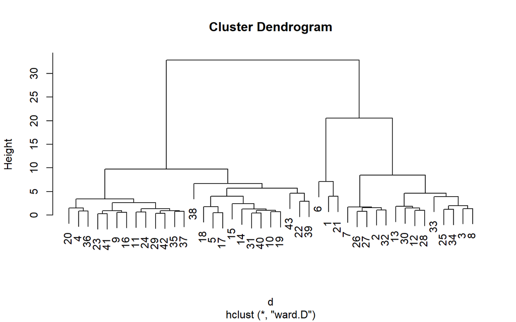

```r
# Graficar el dendograma
plot(fit)
```

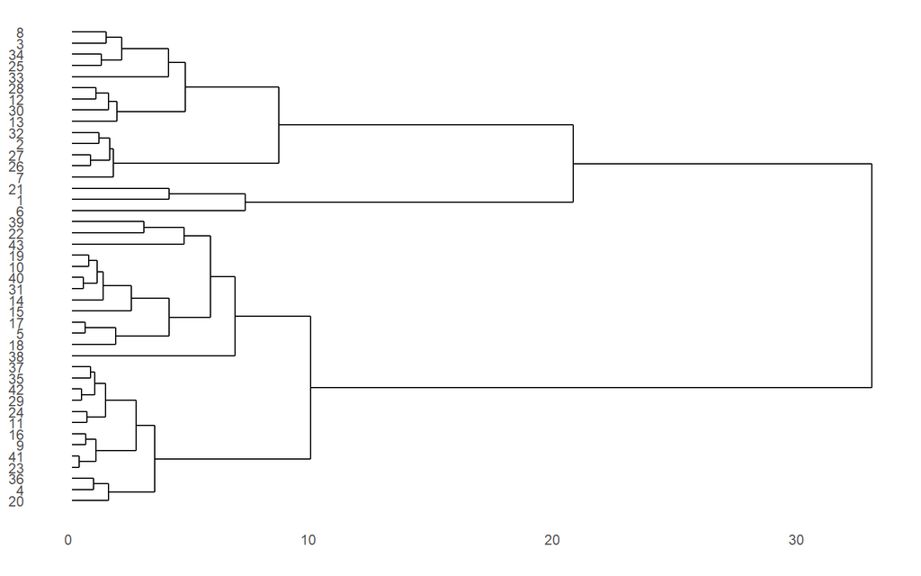

```r
# Otra forma de presentar el dendograma
ggdendrogram(fit, rotate = TRUE, size = 2)
```

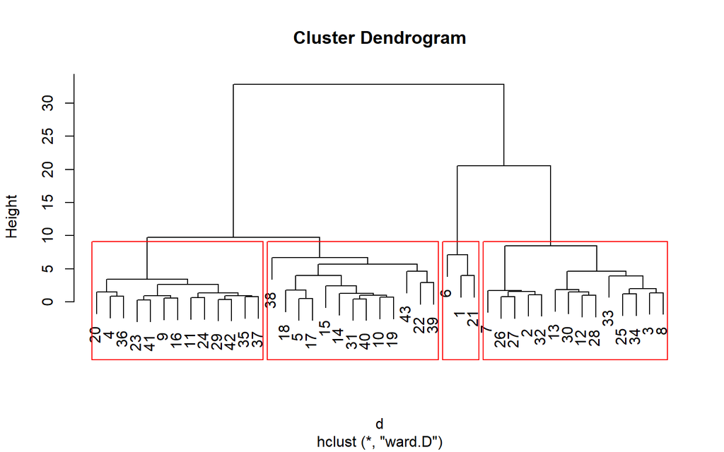

```r
# Graficar el dendograma
plot(fit)

# Indentificar los distintos clusters elegidos
rect.hclust(fit, k = 4, border = "red")
```

## *1.5* ¿Existe alguna manera de determinar el número óptimo de clusters a considerar?

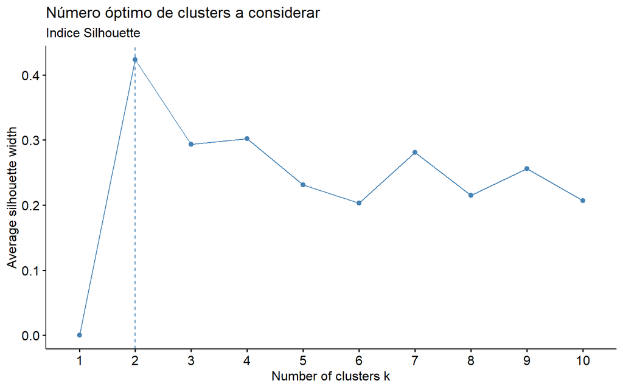

```r
# Indice Silhouette  ---
fviz_nbclust(df_to_cluster, kmeans, method = "silhouette") +
  labs(title    = "Número óptimo de clusters a considerar",
       subtitle = "Indice Silhouette")
```

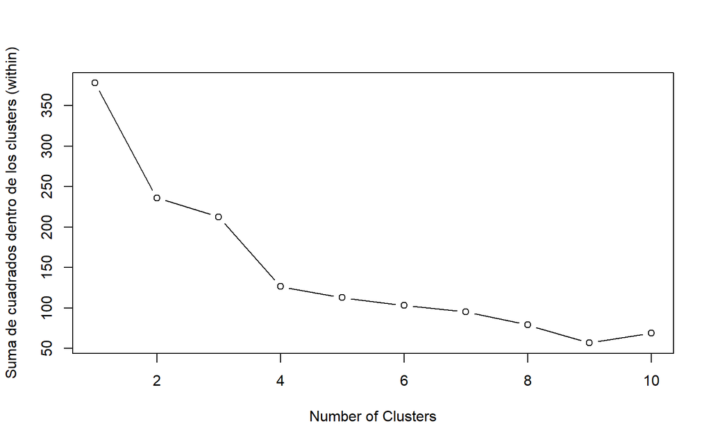

```r
# Suma de cuadrado error (o within)---
wss <- (nrow(df_to_cluster) - 1) * sum(apply(df_to_cluster, 2, var))
for (i in 2:10) {
  wss[i] <- sum(kmeans(df_to_cluster, centers = i)$withinss)
}
plot(1:10, wss, type = "b", xlab = "Number of Clusters",
     ylab = "Suma de cuadrados dentro de los clusters (within)")
```

## *1.6* ¿ Qué características tienen los grupos formados?

Para caracterizar a los grupos formados, simplemente realizamos un análisis descriptivo de los mismos.

Lo podemos realizar sobre las variables originales o sobre las variables estandarizadas que utilizamos para realizar el agrupamiento.

La descripción puede ser simple o bien detallada. A continuación se presentan algunas opciones de caracterización de los grupos elegidos ( utilizando las variables originales).

Se decide trabajar con 4 clusters

```r
groups <- cutree(fit, k = 4)
```

Unir los clusters formado con los datos para poder describir los grupos

```r
df_to_cluster         <- data.frame(df_to_cluster)
df_to_cluster$cluster <- groups # Guarda los cluster en conjunto de datos estandarizdo que se utilizó para agrupar
df$cluster            <- groups # Guarda los cluster en conjunto de datos original
```

### Medias de las distintas variables para los clusters elegidos.

```r
# calcular medias por grupos para todas las variables
df_means <- data.frame(
  df %>%
    group_by(cluster) %>%
    summarise_at(vars(vars_to_cluster), list(name = mean))
)

# Transponer el df de las medias
df_means_t = setNames(data.frame(t(df_means[, -1])), df_means[, 1] )

kable(df_means_t, digits = 1)
```

|  | 1 | 2 | 3 | 4 |
| --- | --- | --- | --- | --- |
| calorias_name | 247.0 | 393.1 | 384.8 | 374.5 |
| proteinas_name | 9.2 | 9.3 | 5.0 | 6.5 |
| carbohidratos_name | 34.2 | 71.1 | 87.9 | 86.6 |
| fibras_name | 34.3 | 5.6 | 1.9 | 5.3 |
| lipidos_name | 13.6 | 8.9 | 1.3 | 1.0 |
| sodio_name | 315.7 | 274.6 | 433.5 | 774.1 |
| potasio_name | 817.7 | 293.2 | 127.4 | 96.8 |
| vitamina_name | 25.5 | 41.7 | 49.6 | 46.2 |
| hierro_name | 10.6 | 8.8 | 10.9 | 13.0 |

### Distribución de las distintas variables según los clusters elegidos.

Para el análsis gráfico de todas las variables a través de los clusters, se crea una función que realiza los gráficos de caja según una variable de interés.

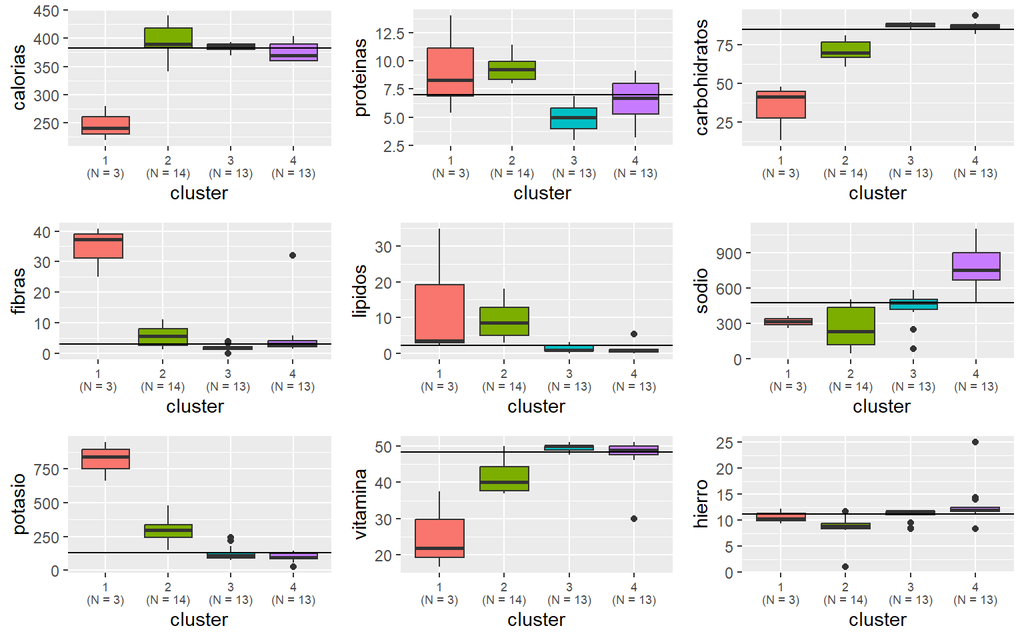

```r
generar_boxplots_por_grupos <- function(df, var_interes, grupos = "cluster") {

  # Convertir a cuadro de datos
  df <- data.frame(df)

  # Definir etiquetas que con la cantidad de observaciones por grupos
  etiquetas <- paste(
    levels(factor(df[, grupos])), "\n(N = ", table(df[, grupos]), ")", sep = ""
  )

  # Generar gráfico
  boxplot <- ggplot(
    df,
    aes(x = factor(get(grupos)), y = get(var_interes),
        fill = factor(get(grupos)))) +
    geom_boxplot() +
    theme(legend.position = "none") +
    scale_x_discrete(name = paste0(grupos), labels = etiquetas) +
    scale_y_continuous(name = paste0(var_interes)) +
    geom_hline(yintercept = median(df[, var_interes])) +
    theme(axis.text.x = element_text(size = rel(0.75)))

  return(boxplot)
}


g1 <- generar_boxplots_por_grupos(df = df, var_interes = "calorias")
g2 <- generar_boxplots_por_grupos(df = df, var_interes = "proteinas")
g3 <- generar_boxplots_por_grupos(df = df, var_interes = "carbohidratos")
g4 <- generar_boxplots_por_grupos(df = df, var_interes = "fibras")
g5 <- generar_boxplots_por_grupos(df = df, var_interes = "lipidos")
g6 <- generar_boxplots_por_grupos(df = df, var_interes = "sodio")
g7 <- generar_boxplots_por_grupos(df = df, var_interes = "potasio")
g8 <- generar_boxplots_por_grupos(df = df, var_interes = "vitamina")
g9 <- generar_boxplots_por_grupos(df = df, var_interes = "hierro")

plot_grid(g1, g2, g3, g4, g5, g6, g7, g8, g9, ncol = 3)
```

Otra forma de generar los gráficos sin escribir el nombre de todas las variables

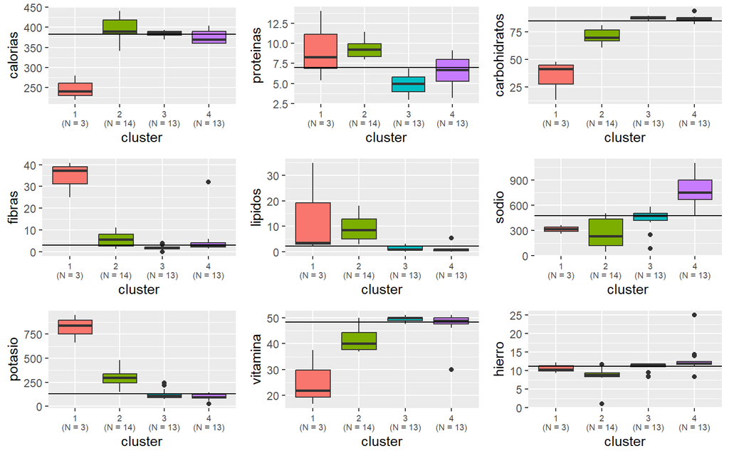

```r
for (j in 1:length(vars_to_cluster)) {
  nombregrafico <- paste0("b", j)
  assign(
    nombregrafico,
    generar_boxplots_por_grupos(df = df, var_interes = vars_to_cluster[j])
  )
}


plot_grid(b1, b2, b3, b4, b5, b6, b7, b8, b9, ncol = 3)
```

```r
# Caracterizar los segmentos encontrados (utilizando las variables originales)
formula_para_describir <- as.formula(
  paste0( paste(vars_to_cluster, collapse = " + "), " ~ cluster")
)

tabla_resumen <- describeBy(
  formula_para_describir,
  mat = TRUE,
  data = df
)
```

### Medidas resúmenes (variables originales) para los clusters elegidos.

```r
kable(
  tabla_resumen %>%
    dplyr::mutate(variable = rownames(.),
                  cv       = 100 * sd / abs(mean)) %>%
    dplyr::rename(cluster = group1) %>%
    dplyr::select(variable, cluster, n, mean, median, cv, min, max) %>%
    arrange(as.numeric(as.character(cluster))),
  digits = 2
)
```

|  | variable | cluster | n | mean | median | cv | min | max |
| --- | --- | --- | --- | --- | --- | --- | --- | --- |
| calorias1 | calorias1 | 1 | 3 | 247.00 | 241.00 | 12.33 | 220.00 | 280.00 |
| proteinas1 | proteinas1 | 1 | 3 | 9.23 | 8.30 | 47.39 | 5.40 | 14.00 |
| carbohidratos1 | carbohidratos1 | 1 | 3 | 34.23 | 41.30 | 53.60 | 13.40 | 48.00 |
| fibras1 | fibras1 | 1 | 3 | 34.30 | 37.20 | 24.03 | 25.00 | 40.70 |
| lipidos1 | lipidos1 | 1 | 3 | 13.57 | 3.50 | 135.60 | 2.40 | 34.80 |
| sodio1 | sodio1 | 1 | 3 | 315.67 | 321.00 | 16.85 | 260.00 | 366.00 |
| potasio1 | potasio1 | 1 | 3 | 817.71 | 840.00 | 17.46 | 665.13 | 948.00 |
| vitamina1 | vitamina1 | 1 | 3 | 25.45 | 22.00 | 42.21 | 16.86 | 37.50 |
| hierro1 | hierro1 | 1 | 3 | 10.63 | 10.31 | 13.52 | 9.38 | 12.20 |
| calorias2 | calorias2 | 2 | 14 | 393.10 | 390.00 | 7.55 | 341.00 | 440.00 |
| proteinas2 | proteinas2 | 2 | 14 | 9.26 | 9.25 | 10.90 | 8.00 | 11.40 |
| carbohidratos2 | carbohidratos2 | 2 | 14 | 71.12 | 69.85 | 9.53 | 60.70 | 81.00 |
| fibras2 | fibras2 | 2 | 14 | 5.59 | 5.50 | 60.05 | 1.21 | 11.00 |
| lipidos2 | lipidos2 | 2 | 14 | 8.93 | 8.50 | 55.43 | 3.00 | 18.00 |
| sodio2 | sodio2 | 2 | 14 | 274.57 | 236.15 | 62.62 | 50.00 | 503.00 |
| potasio2 | potasio2 | 2 | 14 | 293.16 | 296.75 | 29.41 | 150.00 | 480.00 |
| vitamina2 | vitamina2 | 2 | 14 | 41.75 | 39.98 | 11.90 | 36.88 | 50.00 |
| hierro2 | hierro2 | 2 | 14 | 8.81 | 8.90 | 28.62 | 1.10 | 11.67 |
| calorias3 | calorias3 | 3 | 13 | 384.85 | 385.80 | 1.77 | 370.00 | 393.00 |
| proteinas3 | proteinas3 | 3 | 13 | 4.97 | 5.00 | 22.32 | 3.00 | 6.90 |
| carbohidratos3 | carbohidratos3 | 3 | 13 | 87.94 | 88.60 | 2.01 | 85.00 | 90.00 |
| fibras3 | fibras3 | 3 | 13 | 1.86 | 1.70 | 51.06 | 0.00 | 3.78 |
| lipidos3 | lipidos3 | 3 | 13 | 1.30 | 0.90 | 88.38 | 0.00 | 3.10 |
| sodio3 | sodio3 | 3 | 13 | 433.51 | 478.00 | 29.94 | 89.50 | 585.00 |
| potasio3 | potasio3 | 3 | 13 | 127.41 | 111.10 | 41.93 | 76.02 | 242.95 |
| vitamina3 | vitamina3 | 3 | 13 | 49.55 | 50.00 | 2.28 | 47.54 | 51.00 |
| hierro3 | hierro3 | 3 | 13 | 10.95 | 11.67 | 11.76 | 8.40 | 11.90 |
| calorias4 | calorias4 | 4 | 13 | 374.47 | 370.00 | 3.99 | 359.00 | 404.00 |
| proteinas4 | proteinas4 | 4 | 13 | 6.52 | 6.70 | 28.08 | 3.20 | 9.10 |
| carbohidratos4 | carbohidratos4 | 4 | 13 | 86.58 | 87.00 | 3.77 | 82.00 | 94.00 |
| fibras4 | fibras4 | 4 | 13 | 5.31 | 3.00 | 152.89 | 1.38 | 32.00 |
| lipidos4 | lipidos4 | 4 | 13 | 0.97 | 0.70 | 143.04 | 0.00 | 5.30 |
| sodio4 | sodio4 | 4 | 13 | 774.05 | 750.00 | 23.00 | 476.90 | 1100.00 |
| potasio4 | potasio4 | 4 | 13 | 96.84 | 94.16 | 33.55 | 27.63 | 144.00 |
| vitamina4 | vitamina4 | 4 | 13 | 46.23 | 48.85 | 15.86 | 30.00 | 51.00 |
| hierro4 | hierro4 | 4 | 13 | 12.97 | 12.00 | 29.95 | 8.40 | 25.00 |

En función de las medias, las distribuciones gráficas y la medidas resúmenes por grupos analizadas, podemos resumir que los cuatro grupos de cereales se caracterizan por:

- **Cluster 1**:

Está formado por sólo 3 productos que presentan valores promedios considerablemente más bajos que el resto de los productos en: calorías, carbohidratos y vitaminas, y además presentan valores medios considerablemente más altos en fibras y potasio.

- **Cluster 2**:

Está formado por 14 productos que se destacan principalmente por tener valores altos en calorías y proteínas y bajos en hierro y sodio.

- **Cluster 3**:

Lo conforman 13 productos con valores bajos de proteínas, fibras y lípidos y valores altos de vitaminas y carbohidratos. Esto grupo también se destaca por la baja dispersión en todas las variables, es decir, que los productos que forman este grupo son muy parecidos en cuanto a su características nutricionales.

- **Cluster 4**:

Lo forman 13 productos que se diferencian principalmente por tener mayores valores de sodio y valores bajos de potasio. Además, poseen valores altos de hierro y carbohidratos y valores bajos de lipidos.

## *1.7* ¿Qué sucede si elegiéramos trabajar con un cluster más? ¿Cuáles de los grupos se divide? ¿en qué se diferencian los nuevos grupos formados?

## *1.8* ¿Cómo se distribuyen las variables categóricas ‘marca’, ’publico’ y ‘paquete’ en los clusters encontrados? ¿Qué se puede interpretar?

## *1.9* A través del análisis de componentes principales realizado previamente, ¿se podía intuir la presencia de distintos grupos y sus características?

## *1.10* Repetir el análisis con otras medida de distancia de *Canberra* y de *Minkowski* con p = 5? . Cambian los grupos formados? Qué esperaría que ocurra con los ‘outliers’?

## *1.11* ¿Cómo se pueden incorporar esas variables categóricas al análisis? ¿Cómo varía el agrupamiento?